# Coding_challenge4_latest

Kiranmayee

2026-02-26

## 1. 4 pts. Explain the following

###a. YAML header - It is the section at the top of R Markdown file. We can modify the settings such as the output document type, author and date.The output will render the way it is given when knitting.

###b. Literate programming - It is the approcah where code, figures, tables the explainations for it are in the same document.It makes it easy for reader to repeat the same analysis.

###Take the code you wrote for coding challenge 3, question 5, and incorporate it into your R markdown file. Some of you have already been doing this, which is great! Your final R markdown file should have the following elements.

###a. At the top of the document, make a clickable link to the manuscript where these data are published. The link is here:  
Noel, Z.A., Roze, L.V., Breunig, M., Trail, F. 2022. Endophytic fungi as promising biocontrol agent to protect wheat from Fusarium graminearum head blight. Plant Disease. https://doi.org/10.1094/PDIS-06-21-1253-RE

###b. Read the data using a relative file path with na.strings option set to “na”. This means you need to put the Mycotoxin.csv file we have used for the past two weeks into your directory, which git tracks.

```r
myco <- read.csv("MycotoxinData.csv",na.strings = "na")
```

###c. Make a separate code chunk for the figures plotting the DON data, 15ADON, and Seedmass, and one for the three combined using ggarrange

```r
library(ggplot2)
library(ggpubr)

cbbPalette <- c("#000000", "#E69F00", "#56B4E9", "#009E73",
                "#F0E442", "#0072B2", "#D55E00", "#CC79A7")
```

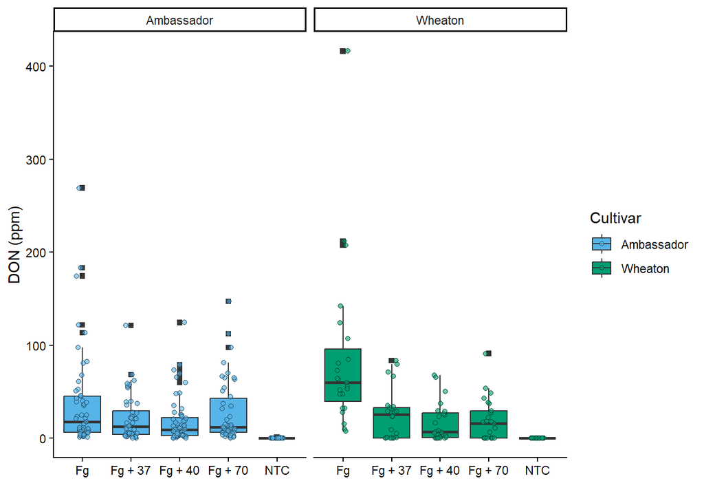

```r
DON_plot <- ggplot(myco, aes(x = Treatment, y = DON, fill = Cultivar)) +
  geom_boxplot(outliers = T, outlier.shape = 15) +
  ylab("DON (ppm)") +
  xlab("") +
  geom_jitter(pch = 21,
              position = position_jitterdodge(),
              color = "black",
              alpha = 0.6) +
  scale_fill_manual(values = c(cbbPalette[[3]], cbbPalette[[4]])) +
  theme_classic() +
  facet_wrap(~Cultivar)

DON_plot
```

DON figure

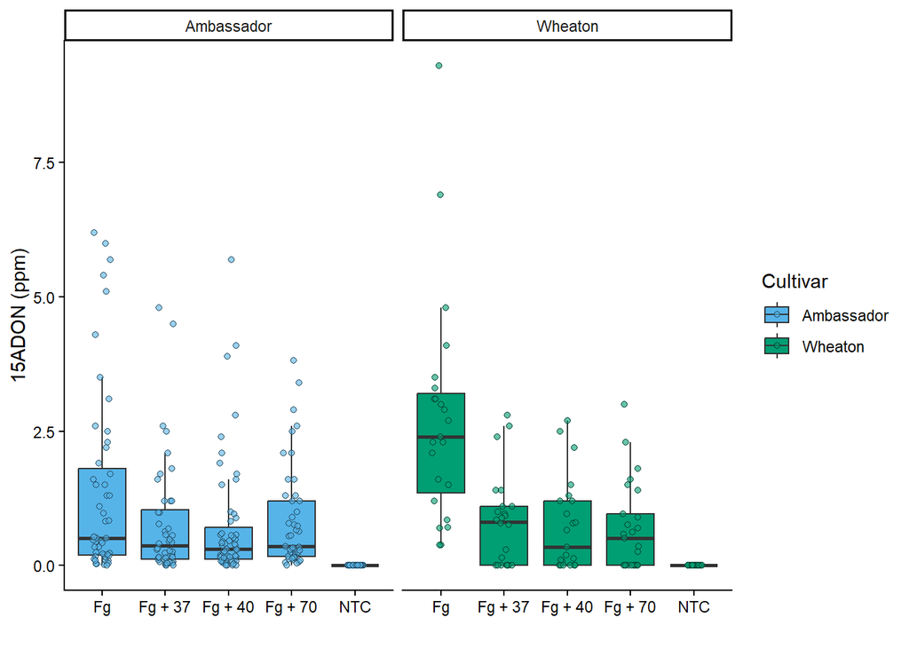

```r
DON_15 <- ggplot(myco, aes(x = Treatment, y = X15ADON, fill = Cultivar)) +
  geom_boxplot(outliers = F) +
  ylab("15ADON (ppm)") +
  xlab("") +
  geom_jitter(pch = 21,
              position = position_jitterdodge(),
              color = "black",
              alpha = 0.6) +
  scale_fill_manual(values = c(cbbPalette[[3]], cbbPalette[[4]])) +
  theme_classic() +
  facet_wrap(~Cultivar)

DON_15
```

15A DON

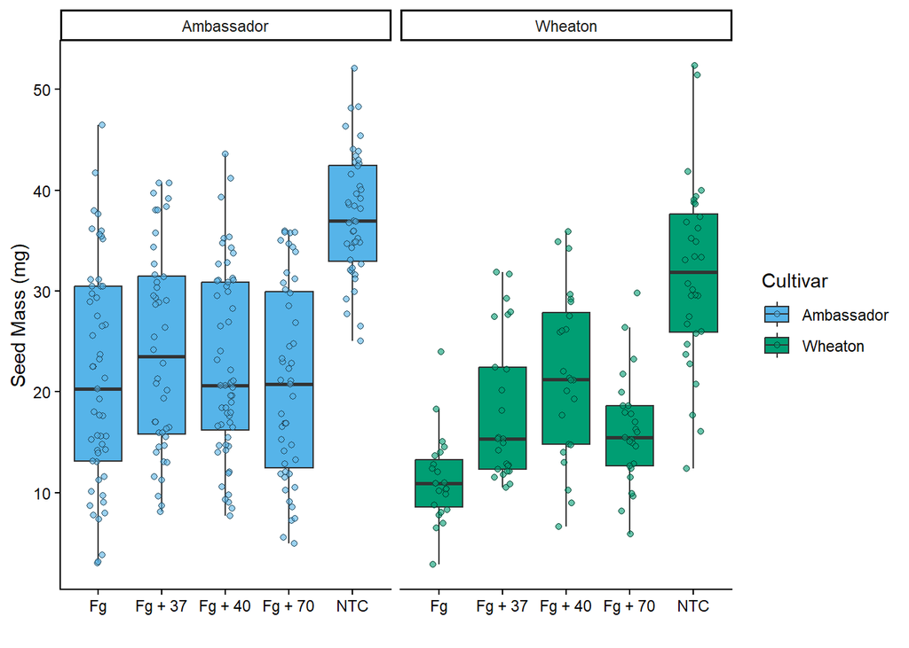

```r
seedmass <- ggplot(myco, aes(x = Treatment, y = MassperSeed_mg, fill = Cultivar)) +
  geom_boxplot(outliers = F) +
  ylab("Seed Mass (mg)") +
  xlab("") +
  geom_jitter(pch = 21,
              position = position_jitterdodge(),
              color = "black",
              alpha = 0.6) +
  scale_fill_manual(values = c(cbbPalette[[3]], cbbPalette[[4]])) +
  theme_classic() +
  facet_wrap(~Cultivar)

seedmass
```

Seedmass

```r
stats_donplot <- DON_plot +
  geom_pwc(aes(group = Treatment),
           method = "t_test",
           label = "{p.adj.format}{p.adj.signif}")

stats_DON_15 <- DON_15 +
  geom_pwc(aes(group = Treatment),
           method = "t_test",
           label = "{p.adj.format}{p.adj.signif}")

stats_seedmass <- seedmass +
  geom_pwc(aes(group = Treatment),
           method = "t_test",
           label = "{p.adj.format}{p.adj.signif}")
```

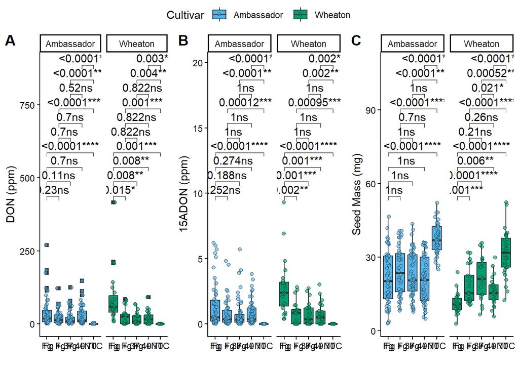

```r
ggarrange(stats_donplot,
          stats_DON_15,
          stats_seedmass,
          labels = c("A", "B", "C"),
          ncol = 3,
          nrow = 1,
          common.legend = TRUE)
```

combine them all together